# Assignment 2 - Functions, iteration, and debugging

RGazzaneo

2024-09-27

```r
# LOAD THE PACKAGES YOU ARE USING IN THIS CODE CHUNK
#install.packages("unvotes")
#install.packages("base")
library(unvotes)
library(dplyr)
library(tidyr)
library(purrr)

options(repos = c(CRAN = "https://cran.r-project.org"))
```

### Task 1 - Warm-up

Program a function `ultimate_answer()` that always returns the number 42 regardless of which input is provided, and show that it works providing three function calls that test different input types!

```r
# YOUR CODE HERE

#42 ultimate answer function
ultimate_answer <- function(...)
{
  return(42)
}

# test function
  test_meaning_of_everything <- function(n) #n being the number of tests to run
  {
  for (i in 1:n) #repets the test n times
    {
      #random input generation of different types of entry
      random_input <- list(
       sample(1:1000, 1), #random integer between 1 and 1000
       paste(sample(letters, 10, replace = TRUE), collapse = ""),#random 10 character string
       sample(c(TRUE, FALSE), 1), #random logical
       runif(5)#random double
      )

      # randomly select an input from list
      input <- random_input[[sample(1:4, 1)]]

      # test the ultimate_answer function
      result <- ultimate_answer(input)

      if (result != 42)
      {
        return(paste("Test failed: ultimate_answer() did not return 42 for input:", input))
      }
    }

  return("42 is definitely is the answer to life, the universe, and everything!")
}

print(paste('ANSWER:',test_meaning_of_everything(3)))
```

```
[1] "ANSWER: 42 is definitely is the answer to life, the universe, and everything!"
```

### Task 2 - The Monty Hall Machine

1. Write an R function that simulates the [Monty Hall problem](https://en.wikipedia.org/wiki/Monty_Hall_problem). Start with writing a function called `monty_hall_choice()` that:
- Simulates a single round of the Monty Hall problem.
- Has an argument switch that controls whether the contestant switches doors after Monty reveals a goat.
- Returns TRUE if the contestant wins the car, and FALSE if they do not. Test it by running it 10 times each with switch = TRUE and switch = FALSE, and summarize the results.

```r
# YOUR CODE HERE

#function that simulates one round of monty hall
#enter the chosen door and if switch TRUE or FALSE for the round

monty_hall_choice <- function(choice1, switch)
{
  monty_doors <- sample(c("goat", "goat", "car"))  # random placement of the car and goats
  available_doors <- setdiff(1:3, choice1) # not chosen doors

  #choose door among the 2 available doors
  a <-sample(available_doors,1)
  b <- monty_doors[a]
  # if chosen door is goat, opens, if not opens the other
  monty_opens <- ifelse(b=="goat", a, setdiff(1:3,c(choice1,a)))

  if (switch) # finds the closed door that was not the 1st chosen and replaces it
  {
    free_door <- setdiff(1:3, c(choice1, monty_opens))
    choice2 <- free_door
  }
  else {choice2 <- choice1}

  # tests if contestant_2nd_choice=car and returns true or false
  return(monty_doors[choice2] == "car")
}

# ====================================================================

#function to run tests 10 on monty_hall_choice()

test_monty_hall <- function(n)
{
  choice1 <- sample(1:3, n, TRUE) #creates random vector w/ chosen door for the n tests
  with_switch <- c() #creates empty vector to summarize n tests w/ switch
  without_switch <- c() #creates empty vector to summarize n tests w/out switch

  for (i in choice1) #run function n times w/ and w/out switch
  {
    with_switch <- c(with_switch, monty_hall_choice(i, switch = TRUE))
    without_switch <- c(without_switch, monty_hall_choice(i, switch = FALSE))
  }

  #summarize results in a table
  return(results <- data.frame(choice1,with_switch,without_switch))
}

print('ANSWER:')
```

```
[1] "ANSWER:"
```

```r
print(results_summary <- test_monty_hall(10))
```

```
   choice1 with_switch without_switch
1        2       FALSE          FALSE
2        1        TRUE           TRUE
3        2        TRUE          FALSE
4        2        TRUE           TRUE
5        1        TRUE          FALSE
6        1       FALSE          FALSE
7        3       FALSE           TRUE
8        3        TRUE          FALSE
9        2        TRUE          FALSE
10       3        TRUE          FALSE
```

2. Now, create a function `monty_hall_simulation()` to simulate multiple rounds of the Monty Hall problem:
- The function should wrap around the `monty_hall_choice()`.
- Add an argument n to the function that specifies how many rounds to simulate.
- The function should return the proportion of times the contestant wins the car for both strategies (switch = TRUE and switch = FALSE).

```r
# YOUR CODE HERE

monty_hall_simulation <- function(n)
{
  choice1 <- sample(1:3, n, TRUE)
  with_switch <- c()
  without_switch <- c()

  for (i in choice1)
  {
    with_switch <- c(with_switch, monty_hall_choice(i, TRUE))
    without_switch <- c(without_switch, monty_hall_choice(i, FALSE))
  }

  results <- data.frame(choice1,with_switch,without_switch)

  #proportion of win w/switch
  p_with = (sum(results$with_switch)/n)
  #proportion of win w/out switch
  p_without = (sum(results$without_switch)/n)

  return(c(p_with,p_without))
}

results<-monty_hall_simulation(10)

cat("ANSWER:\n Proportion of wins with switch:", results[1]*100, "%\n Proportion of wins without switch:", results[2]*100, "%" )
```

```
ANSWER:
 Proportion of wins with switch: 40 %
 Proportion of wins without switch: 10 %
```

3. **Bonus challenge:** Generalize the Monty Hall Problem to k doors and k-1 goats, where the host will open all doors except for 2. Now, visualize the probability of winning (proportion of wins) for both strategies (switch and stay) as a function of the number of simulated rounds n and the number of doors k, for a set of values for both n and k that you choose. *Important:* This is just for fun. You don’t have to work on this task if you don’t have time. Providing a right/wrong solution does not give/cost you extra points. (A right solution gives you kudos from the instructor though!)

```r
# YOUR CODE HERE

#################################################################################################
#                                                                                               #
#       WARNING: This code has a bug                                                            #
#                                                                                               #
#       The function k_monty_hall_choice randomly return the following error:                   #
#                                                                                               #
#           Error in sample.int(length(x), size, replace, prob) :                               #
#            invalid first argument                                                             #
#                                                                                               #
#       Apparently it occurs whenever available_doors returns an integer(0)                     #
#       However, it was not supposed to happen, any insides on it will be deeply appreciated    #
#                                                                                               #
#       WORK AROUND: on k_monty_hall_choice, I replaced the error for NULL                      #
#                    when k_monty_hall_simulation gets NULL, it ignores it and run again        #
#                                                                                               #
#################################################################################################

k_monty_hall_choice <- function(choice, switch, k)
{
  tryCatch(
    {
      monty_doors <- rep("goat", k) # creates goat vector
      monty_doors [sample(1:k, 1)] <- "car" # random placement of the car
      monty_opens <- NULL
      available_doors <- c(1:k)

      while(length(available_doors) >= 2)
           {
              available_doors<-setdiff(1:k,c(choice,monty_opens))# not chosen doors
              a <-sample(available_doors,1)#choose door among the available doors
              b <- monty_doors[a]

              # if chosen door is goat, opens, if not opens the other
              monty_opens <- ifelse(b=="goat", a, sample(1:k,sample(setdiff(available_doors, a),1)))

              if (switch==TRUE) # finds the closed door that was not the 1st chosen and replaces it
                  {
                      choice <- sample(available_doors,1)
                  }

              k=k-1
            }

      #tests if contestant_2nd_choice=car and returns true or false
      return(monty_doors[choice] == "car")
    },error = function(e) {return(NULL)})
}

#=====================================================================

k_monty_hall_simulation <- function(n, k)
{
  choice <- sample(1:k, n, TRUE)
  with_switch <- c()
  without_switch <- c()

  for (i in choice)
  {
    a <- NULL
    while(is.null(a))
    {a <- k_monty_hall_choice(i, TRUE,k)}
    with_switch <- c(with_switch, a)

    b <- NULL
    while(is.null(b))
    {b <- k_monty_hall_choice(i, FALSE,k)}
    without_switch <- c(without_switch, b)
  }

  results <- data.frame(choice,with_switch,without_switch)

  #proportion of win w/switch
  p_with = (sum(results$with_switch)/n)
  #proportion of win w/out switch
  p_without = (sum(results$without_switch)/n)

  return(c(p_with,p_without))
}

results<- k_monty_hall_simulation(10, 10)

cat("ANSWER:\n Proportion of wins with switch:", results[1]*100, "%\n Proportion of wins without switch:", results[2]*100, "%" )
```

```
ANSWER:
 Proportion of wins with switch: 0 %
 Proportion of wins without switch: 0 %
```

### Task 3 - Functional programming in practice

The `unvotes` package (hosted both on [CRAN](https://cran.r-project.org/web/packages/unvotes/index.html) and [GitHub](https://github.com/dgrtwo/unvotes)) provides data on the voting history of countries in the [United Nations General Assembly](http://www.un.org/en/ga/), along with information such as date, description, and topics for each vote. The package contains three datasets: `un_votes`, providing the history of each country’s votes, `un_roll_calls`, providing information on each roll call vote, and `un_roll_call_issues`, providing issue (topic) classifications of roll call votes. Check out the [database tutorial](https://github.com/dgrtwo/unvotes) if you want to make yourself familiar with the data structure. Then, work on the following tasks.

```r
# YOUR CODE HERE

###disclaimer###
# after structuring the sequence of the code, I used chatGPT to convert ass the steps into pipeline
# also heavily used in b)
```

1. Calculate how often, on average, Germany agreed with the US on a vote in the UN general assembly since 1995. Votes where voting information for one of the countries is missing should be discarded.

```r
# YOUR CODE HERE

average_agreement <- un_votes %>%
  inner_join(un_roll_calls, by = "rcid") %>% #inner_join un_votes and un_roll_calls, by "rcid"
  mutate(year = as.numeric(substring(date, 1, 4))) %>%  #extract year
  filter(year >= 1995, country %in% c("Germany", "United States")) %>%  #filter year
  filter(!is.na(vote)) %>%  #cleaning missing votes
  select(year, country, vote) %>%  #select needed columns
  group_by(year, country) %>%  #group by year and country
  summarise(vote = first(vote), .groups = "drop") %>%  #summarise
  pivot_wider(names_from = country, values_from = vote) %>%  #from long to wide
  filter(!is.na(Germany), !is.na(`United States`)) %>%  #cleaning missing votes
  mutate(agreement = ifelse(Germany == `United States`, 1, 0)) %>%  #agreement column
  summarise(average_agreement = mean(agreement) * 100, .groups = "drop")  #calc percentage avarage

cat("ANSWER:",as.numeric(average_agreement$average_agreement),"%")
```

```
ANSWER: 28 %
```

2. Now, create a function, `votes_agreement_calculator()`, that takes country identifiers as well as a `year_min` argument as inputs and that returns the share of agreement in voting between any two specified countries as numeric value, for a time period specified with year >= `year_min`. The function should take the necessary data frames directly from the `unvotes` package. Then, test the function by computing the agreement rates for (a) the United States and Russia for votes cast in 2000 and later and (b) France and the UK for votes cast in 2000 and later!

```r
# YOUR CODE HERE

votes_agreement_calculator <- function(country1, country2, year_min) {
  # load tables
  data("un_votes")
  data("un_roll_calls")

  votes_filtered <- un_votes %>%
    filter(country %in% c(country1, country2)) %>% #filter country 1 and 2
    inner_join(un_roll_calls %>%
                 filter(date >= as.Date(paste0(year_min, "-01-01"))), by = "rcid")#filter year

  # Pivot the data so each row contains both countries' votes for each roll call (chatGPT)
  votes_pivot <- votes_filtered %>%
    select(rcid, country, vote) %>%
    pivot_wider(names_from = country, values_from = vote, names_prefix = "vote_") %>%
    filter(!is.na(!!sym(paste0("vote_", country1))), !is.na(!!sym(paste0("vote_", country2))))

  votes_pivot <- votes_pivot %>%
    mutate(agreed = !!sym(paste0("vote_", country1)) == !!sym(paste0("vote_", country2)))#agreed column

  agreement_rate <- mean(votes_pivot$agreed)#avarage rate
  return(agreement_rate)
}

us_russia_agreement <- votes_agreement_calculator("United States", "Russia", 2000)
france_uk_agreement <- votes_agreement_calculator("France", "United Kingdom", 2000)

cat("ANSWER: a)", us_russia_agreement* 100,"% | b)",france_uk_agreement*100,"%")
```

```
ANSWER: a) 24.60447 % | b) 92.44976 %
```

3. Using `purrr` functionality, find out which three countries on average agreed with the US the most from the year 2000 on!

```r
# YOUR CODE HERE

top_agreeing_countries <- function(input_country, year_min)
  {

    data("un_votes")

    countries <- un_votes %>%
      distinct(country) %>%
      filter(country != input_country) %>%
      pull(country)

    safe_agreement_calculator <- safely(votes_agreement_calculator)
    #(purrr) maps countries and calculate agreement rates
     agreement_rates <- map_dfr(countries, function(country)
       {
        result <- safe_agreement_calculator(input_country, country, year_min)

        # Check if the result contains an error
        if (!is.null(result$error))
          {
            agreement_rate <- 0
          }else{agreement_rate <- result$result}

    tibble(country = country, agreement_rate = agreement_rate)
  })

    #get top_3
    top_countries <- agreement_rates %>%
      filter(!is.na(agreement_rate)) %>%  # Remove NA rates
      arrange(desc(agreement_rate)) %>%
      head(3)

    return(top_countries)
  }

print(top_agreeing_countries("United States", 2000))
```

```
# A tibble: 3 × 2
  country                          agreement_rate
  <chr>                                     <dbl>
1 Israel                                    0.795
2 Micronesia (Federated States of)          0.736
3 Palau                                     0.691
```

### Task 4 - Debugging code

The following code is meant to create a bar chart showing the average height of Star Wars characters by their species, with text labels displaying the number of characters belonging to each species and arranged by average height in decreasing order. The data ships with the `dplyr` package. However, the code contains multiple bugs. Fix them. As proof, the HTML should include the plot that is generated by the code.

```r
library("ggplot2", "dplyr")

# Group characters by species and calculate summary statistics
species_data <- star_wars %>%
  group.by(species) %>%
  summarise(
    avg_height = mean(height),
    num_characters = count()
  ) %>%
  arrange(avg_height)

# Plotting the results
ggplot(species_data, aes(x = species, y = avg_height)) +
  geom_bar(stat = bar, aes(fill = avg_height))
  geom_text(aes(label = num_characters), vjust = "top")
  xlab("Species") +
  ylab("Average Height") +
  title("Average Height by Species")
# Setting color scale
scale_color_gradient(low = "blue", high = "red")
```

STEP 1: Guaranteed that the dataframe is available and loaded properly

```
    > install.packages("dplyr")
    > library(ggplot2)
    > library(dplyr)
    > head(starwars)
```

STEP 2: Fix of minor issues

Issues detected:

- group.by() -> group_by()
- count() -> n()
- stat = bar -> stat = “identity”
- title() -> ggtitle()
- scale_color_gradient() -> scale_fill_gradient()

STEP 3: To print the plot removed ‘eval = FALSE’, assigned the plot to a variable ‘image_plot’ and used function print.

```r
library(ggplot2)
library(dplyr)

head(starwars)
```

```
# A tibble: 6 × 14
  name      height  mass hair_color skin_color eye_color birth_year sex   gender
  <chr>      <int> <dbl> <chr>      <chr>      <chr>          <dbl> <chr> <chr>
1 Luke Sky…    172    77 blond      fair       blue            19   male  mascu…
2 C-3PO        167    75 <NA>       gold       yellow         112   none  mascu…
3 R2-D2         96    32 <NA>       white, bl… red             33   none  mascu…
4 Darth Va…    202   136 none       white      yellow          41.9 male  mascu…
5 Leia Org…    150    49 brown      light      brown           19   fema… femin…
6 Owen Lars    178   120 brown, gr… light      blue            52   male  mascu…
# ℹ 5 more variables: homeworld <chr>, species <chr>, films <list>,
#   vehicles <list>, starships <list>
```

```r
species_data <- starwars %>%
  group_by(species) %>%
  summarise(
    avg_height = mean(height, na.rm = TRUE),
    num_characters = n()
  ) %>%
  arrange(desc(avg_height))

image_plot <- ggplot(species_data, aes(x = species, y = avg_height)) +
  geom_bar(stat = "identity", aes(fill = avg_height)) +
  geom_text(aes(label = num_characters), vjust = "top") +
  xlab("Species") +
  ylab("Average Height") +
  ggtitle("Average Height by Species") +
  scale_fill_gradient(low = "blue", high = "red")
```

STEP 4: Reorder the plot and fix labels

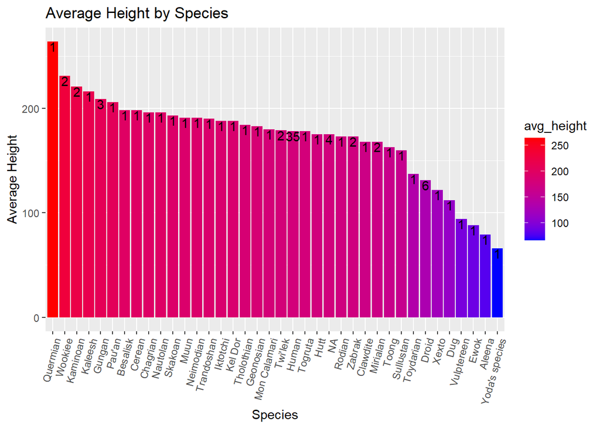

```r
species_data <- starwars %>%
  mutate(species = replace_na(species, "NA")) %>% #rename NA otherwise its not reorderd
  group_by(species) %>%
  summarise(
    avg_height = mean(height, na.rm = TRUE),
    num_characters = n()
  ) %>%
  arrange(desc(avg_height))

image_plot <- ggplot(species_data, aes(x = reorder(species, -avg_height), y = avg_height)) +
  geom_bar(stat = "identity", aes(fill = avg_height)) +
  geom_text(aes(label = num_characters), vjust = "top", angle = 0, hjust = 0.5) +
  xlab("Species") +
  ylab("Average Height") +
  ggtitle("Average Height by Species") +
  scale_fill_gradient(low = "blue", high = "red")
  image_plot + theme(axis.text.x = element_text(angle = 75, vjust = 1, hjust=1))
```